# Club Recommender for David Horsey

Matt Mills

# Introduction

Club choice can be one of the biggest decisions a golfer makes on the course. Many inputs affect this decision such as pin location, conditions, distance to the pin, and the lie of the ball. In this paper I present a method to find the optimal club choice for David Horsey by using models for estimating the value of a shot and the impact of club type, lie, and distance to the pin. These were used to find the expected strokes gained from picking one club type over another given the lie and distance to the pin. The dataset was limited to the type of club (driver, fw wood, hybrid, iron, putter, wedge), the distance from the pin, and the type of lie of the ball from 14 tournaments. The methods for finding the value of each club should be generalizable to more information like club number, x/y position on the course, playing conditions, and other information. First a model is built to estimate the expected number of remaining strokes on a hole given Mr. Horsey’s distance to the pin and current lie. Then the value of each shot is measured by comparing the expected number of strokes before and after the shot, with an expected strokes remaining of 0 once the ball is in the hole. Then a model is built that attempts to predict the expected shot value given the club used, current lie, and distance to the pin. This model can then be used to find the expected strokes gained from picking a certain club for a shot.

## A Model for Estimating Strokes Remaining

The perspective of this model considers the quality of a player’s position before a shot using this formula.

$$shot\_value = f(pin\_distance, current\_lie)$$

This model was estimated using an ordinal generalized additive model using seperate smoothing splines for each type of lie. In R this was fit using the `mgcv` package with the following call:

```r
shots <- shots %>%
  mutate(shots_remaining = score - shot_no + 1)
shots$lie_before_factor <- as.factor(shots$lie_before)
## GAM needs the by variable to be a factor

cats <- sort(unique(shots$shots_remaining))
ordered_model <- gam(shots_remaining ~ s(left_to_pin_before, by = lie_before_factor),
                     data = shots,
                     family = ocat(theta = cats[c(-1, -8)]))
## gam uses -1 as the first cut level and the last category doesn't need a cut variable
```

This model was chosen because of the insight that can be gained by having seperate models for completing the hole in a certain number of shots. However a Poisson model will generate very similar predictions (correlation of .98).

An example of the model output can be seen below:

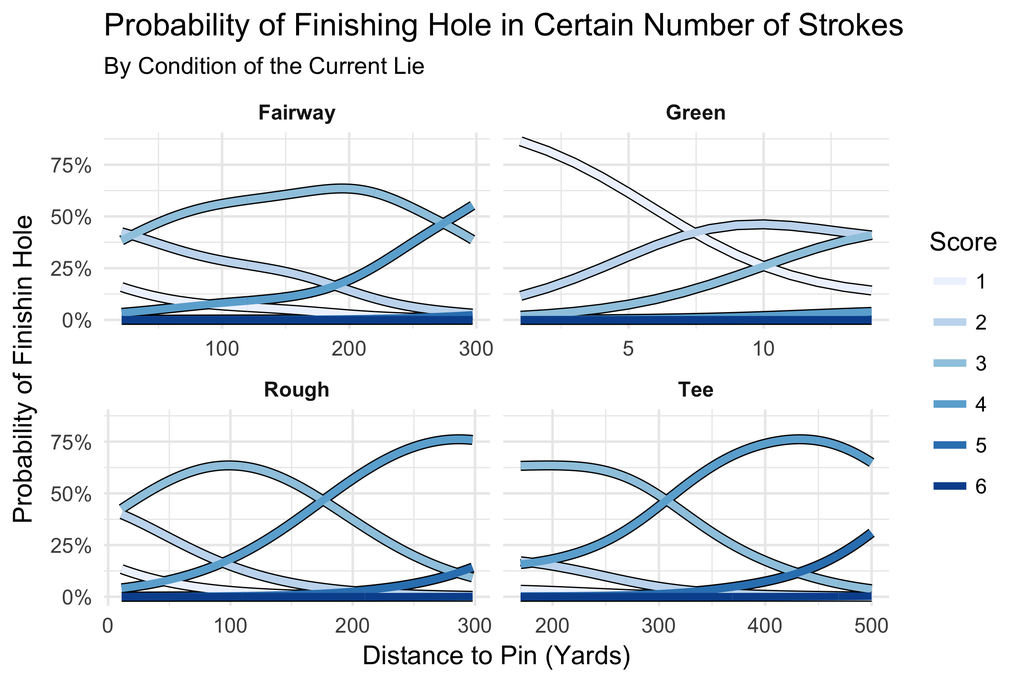

The probability distributions for the underlying remaining strokes on the hole are used to get an estimated number of shots remaining. Here is an example of the results of this model from the DP World Tour Championship in Dubai on the Par-5 18th hole in the 2nd round:

| Shot Number | Distance to Pin (Yards) | Current Lie | Predicted Shots Remaining |
| --- | --- | --- | --- |
| 1 | 540 | Tee | 4.47 |
| 2 | 259 | Fairway | 3.36 |
| 3 | 70 | Fairway | 2.56 |
| 4 | 2 | Green | 1.21 |

A full picture of the expected shots remaining for a givin lie and distance can be seen below.

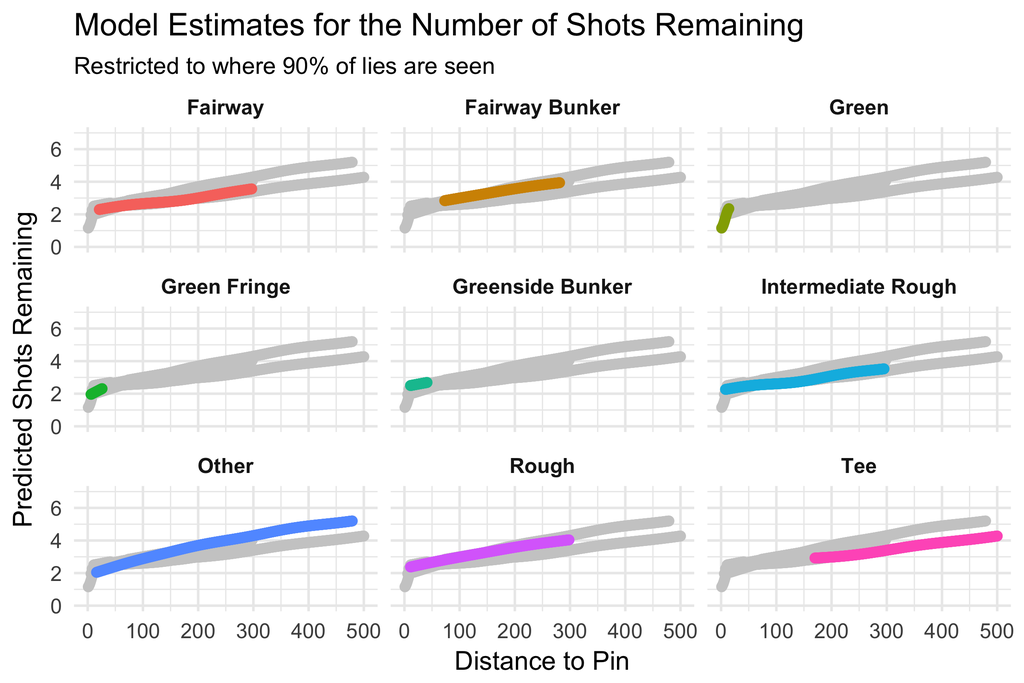

It should be said that this expected shots model is actually a “Expected Shots Remaining given the courses David Horesy played in 2016”; It doesn’t have as nice of a ring to it but it is more accurate. With more shot data from more players and more tournaments the generalizability of this model should increase.

## Strokes Gained During a Shot

Now that we have an estimate for the number of strokes remaining given a shot’s conditions we can find an estimate for the strokes gained once a shot has been completed.

$$strokes\_gained = expected\_shots\_remaining_{before} - expected\_shots\_remaining_{after}$$

Using the 18th hole of the 2nd round of the World Championships as our example again we can see how this strokes gained score is calculated:

| Shot Number | Distance to Pin (Yards) | Current Lie | Shots Remaining Before | Shots Remaining After | Strokes Gained |
| --- | --- | --- | --- | --- | --- |
| 1 | 540 | Tee | 4.47 | 3.36 | 1.11 |
| 2 | 259 | Fairway | 3.36 | 2.56 | 0.81 |
| 3 | 70 | Fairway | 2.56 | 1.21 | 1.34 |
| 4 | 2 | Green | 1.21 | 0.00 | 1.21 |

## A Model for Estimating the Strokes Gained for a Shot

Now that we have an estimate for the strokes gained during a shot we can attempt to measure the value of club choice. This is done by using the following model:

$$strokes\_gained = f(club\_choice | distance) + f(current\_lie | distance)$$

The rationale for this model is that certain club types are better at different distances and different lies have different effects on each club.

This model is fit using another generalized additive model with different smoothing splines estimated for each club type and each lie and is shown below. With this construct we have an estimate for impact of club choice on the strokes gained during a shot given that shot’s distance and current lie.

```r
shot_value$club_factor <- factor(shot_value$club)

club_gam <- gam(shot_value ~ s(left_to_pin_before, by = club_factor) + s(left_to_pin_before, by = lie_before_factor),
                data = mutate(shot_value, lie_before_factor = factor(lie_before)))
```

Now that our model is built we can visualize the impact of club choice by different lies and distances:

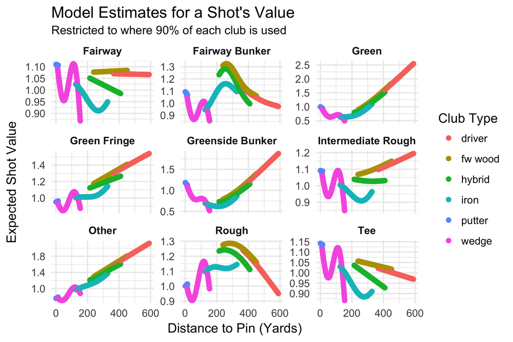